# Writing a Reproducible Paper in R with WORCS

This workshop will give you an overview of the workflow and introduce you to its use, and aim for you to be able to get started on your own reproducible project. **If you’re attending the workshop, make sure to check the Preparation paragraph**.

## Why?

Open Science is becoming increasingly popular and relevant, and a world of opportunity is opening up to make your work fully reproducible. This is not without its challenges: best practices for reproducible science include a number of tools that you may never have used or even heard of before. *(Are you using version control? How are you managing your dependencies? Are you writing your manuscript as an executable document?)*

WORCS is an R package that takes you from data to published paper in a single streamlined workflow, making the entire process of your analysis, up to the submission of your manuscript, reproducible. The WORCS workflow optionally facilitates pre-registration, sharing your code and your data (safely!), and the submission of a pre-print.

## Target audience

Anyone who would like to get started with an open and reproducible workflow, without dealing with a mountain of new tools and platforms. The workshop uses R, but prior experience is not required. Having the motivation to step out of your comfort zone — and into a new one — is the most important prerequisite.

## Desired outcome

Attendees will be able to get started on their own open, reproducible project by the end of the workshop.

## Preparation

1. Setup your laptop by following the [Setup vignette: Setting up your computer for WORCS](https://cjvanlissa.github.io/worcs/articles/setup.html) (NOTE: Reserve 1 hour to do this)
2. Bring your own dataset (optionally: analysis code) that you want to make reproducible
   - If you don’t have your own data, you can use some demo data.
   - For example, [these data](https://github.com/cjvanlissa/demo_metarep/blob/1366250e87b9b3efd164e1f6d2a1d5e6158c0602/df.csv) on the effect of different methods of drying the hands on hang time in rock climbing.
   - Alternatively, the classic [Allison Horst’s Penguin dataset](https://github.com/allisonhorst/palmerpenguins):
     - [CSV file](https://raw.githubusercontent.com/bvreede/worcshop/master/data/penguins.csv)
     - [SPSS file](https://raw.githubusercontent.com/bvreede/worcshop/master/data/penguins.sav)
     - [Excel file](https://raw.githubusercontent.com/bvreede/worcshop/master/data/penguins.xlsx)

## Worcshop slides and documentation

### Workflow demonstration:

[Setting up a `worcs` project in RStudio](https://cjvanlissa.github.io/worcs/articles/workflow.html)

### Presentations (by event):

- [turku (Mar 26)](https://cjvanlissa.github.io/worcshop/turku.html)
- [ic2s2 (Jul 25)](https://cjvanlissa.github.io/worcshop/ic2s2.html)
- [meehl (Oct 24)](https://cjvanlissa.github.io/worcshop/meehl.html)
- [Porto_2023 (Dec 23)](https://cjvanlissa.github.io/worcshop/Porto_2023.html)
- [Code_cafe_2023 (Nov 23)](https://cjvanlissa.github.io/worcshop/Code_cafe_2023.html)
- [eara2020 (Nov 23)](https://cjvanlissa.github.io/worcshop/eara2020.html)
- [eur_2020 (Nov 23)](https://cjvanlissa.github.io/worcshop/eur_2020.html)
- [MPIB_2020 (Nov 23)](https://cjvanlissa.github.io/worcshop/MPIB_2020.html)
- [OSFestival_2022 (Nov 23)](https://cjvanlissa.github.io/worcshop/OSFestival_2022.html)
- [overview_lecture (Nov 23)](https://cjvanlissa.github.io/worcshop/overview_lecture.html)
- [SRA_2021 (Nov 23)](https://cjvanlissa.github.io/worcshop/SRA_2021.html)
- [SRCD_2021 (Nov 23)](https://cjvanlissa.github.io/worcshop/SRCD_2021.html)

## Video Tutorials

### Introduction to WORCS

[figure not shown]

### Creating a new WORCS Project

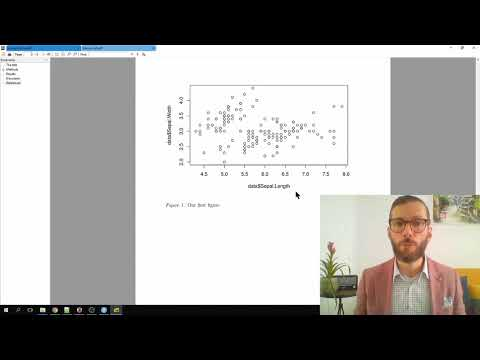

### Make Existing R Code Reproducible with ‘worcs’ and ‘targets’

[figure not shown]

## Further reading

- [Read the preprint](https://psyarxiv.com/k4wde/)
- The [worcs GitHub repo](https://github.com/cjvanlissa/worcs)
- [Markdown cheat sheet](https://www.markdownguide.org/cheat-sheet)

## Links submitted during the workshop

- [TOP guidelines](https://www.cos.io/our-services/top-guidelines)
- [Git User Interfaces](https://git-scm.com/downloads/guis) - recommendation by workshop participant: [GitKraken](https://www.gitkraken.com/)
- rrtools, an attempt to streamline containerization in R